# Step 3: Geocoding Addresses through Census

3/19/2019

# Introduction

PENDING:

- Fix results files
- provide intro to census service and info on added variables and results (no match exact non exact, tie, etc.)
- Include troubleshooting section with examples
- what happened to the addresses that are “—-”? and what happened to the NPO IDs that are not unique?

In this script we will geocode NPO and PPL addresses using the Census Bureau geocoding service. The new dataset will be saved as a new version of the main files **NONPROFITS-2014-2019v3.rds** and **PEOPLE-2014-2019v3.rds**.

**Steps**

1. We will load the **NONPROFIT-2014-2019v2.rds** and **PEOPLE-2014-2019v2.rds** files and produce input files **NPOAddresses_census.rds** and **PPLAddresses_census.rds**. These hold the data that will be passed through the geocoding service.
2. Intro and demo of the Census geocoding service.
3. Geocoding NPO addressess (**NPOAddresses_census.rds**) through the Census geocoding service. The script will yield raw output file **NPOAddresses_censusGEO.rds**. The new geocode information will be integrated into a new version of the main file **NONPROFIT-2014-2019v3.rds**
4. Geocoding PPL addressess (**PPLAddresses_census.rds**) through the Census geocoding service. The script will yield raw output file **PPLAddresses_censusGEO.rds**. The new geocode information will be integrated into a new version of the main file **PEOPLE-2014-2019v3.rds**
5. Troubleshooting

**Notes** * This script includes a troubleshooting section. * Geocoding can take several hours, for this reason some code chunks in this script are not evaluated. Outputs yielded from the process are loaded from stored files to ilustrate the results.

**Packages**

```r
library( dplyr )
library( tidyr )
library( pander )
library( httr )

# update the path with your working directory:
wd <- "/Users/icps86/Dropbox/R Projects/Open_data_ignacio"
setwd(wd)
```

# 1. Subsetting input files

For the Census geocoding, addresses should be formatted in the following fields:

- Unique ID,
- House Number and Street Name,
- City,
- State,
- ZIP Code

CREATING Address files **NPOAddresses_census.rds** and **PPLAddresses_census.rds**

## 1.1 Creating a NPO input_address dataset

```r
npo <- readRDS( "Data/2_InputData/NONPROFITS-2014-2019v2.rds" )

npo$input_address <- paste(npo$Address, npo$City, npo$State, npo$Zip, sep = ", ") #creating an input_address field to match the geocode dataframes
npo <- npo[,c(1,73,12:15,71)]
npo$ID <- 0
npo <- unique(npo)
npo <- npo[order(npo$input_address),]
npo$ID <- 1:nrow(npo)
rownames(npo) <- NULL

saveRDS(npo, "Data/3_GeoCensus/NPOAddresses_census.rds")
```

## 1.2 Creating a PPL input_address dataset

```r
ppl <- readRDS( "Data/2_InputData/PEOPLE-2014-2019v2.rds" )

ppl$input_address <- paste(ppl$Address, ppl$City, ppl$State, ppl$Zip, sep = ", ") #creating an input_address field to match the geocode dataframes

ppl <- ppl[,c(1,21,11:14,19)]
ppl$ID <- 0
ppl <- unique(ppl)

ppl <- ppl[order(ppl$input_address),]
ppl$ID <- 1:nrow(ppl)
rownames(ppl) <- NULL

saveRDS(ppl, "Data/3_GeoCensus/PPLAddresses_census.rds")
```

# 2. Demo: The Census Geocoding Service

Additional information about the geocoding service can be found here:

- DOCUMENTATION: https://www.census.gov/programs-surveys/geography.html
- WEB GEOCODING SERVICE: https://geocoding.geo.census.gov/geocoder/geographies/addressbatch?form

This section runs a Demo to test the code is working. Addresses should be formatted in the following fields:

- Unique ID,
- House Number and Street Name,
- City,
- State,
- ZIP Code

Geocode adds the following variables to the dataset:

- match
- match_type
- out_address
- lat_lon
- tiger_line_id
- tiger_line_side
- state_fips
- county_fips
- tract_fips
- block_fips
- lon
- lat

Loading the Board Members Dataset (PPL) dataset and subsetting only key variables to test the demo

```r
# loading rds
ppl <- readRDS( "Data/3_GeoCensus/PPLAddresses_census.rds")

# create a demo folder if needed:
# dir.create( "Data/3_GeoCensus/demo" )

# subsetting
demo <- select( ppl, ID, Address, City, State, Zip )
x <- sample(nrow(ppl),20, replace = FALSE)
demo <- demo[ x, ]
rownames(demo) <- NULL

# writing a csv file with the address list to feed into the geocode process
write.csv( demo, "Data/3_GeoCensus/demo/TestAddresses.csv", row.names=F )
```

In the following code chunk we are executing the geocode query and storing results as csv files.

```r
# temporarily setting the working directory for geocode
wd2 <- paste0(wd, "/Data/3_GeoCensus/demo")
setwd(wd2)

# creating a url and file path to use in the geocode query
apiurl <- "https://geocoding.geo.census.gov/geocoder/geographies/addressbatch"
addressFile <- "TestAddresses.csv"

# geocode query
resp <- POST( apiurl,
              body=list(addressFile=upload_file(addressFile),
                        benchmark="Public_AR_Census2010",
                        vintage="Census2010_Census2010",
                        returntype="csv" ),
              encode="multipart" )

# Writing results in a csv using writelines function
var_names <- c( "id", "input_address",
                "match", "match_type",
                "out_address", "lat_lon",
                "tiger_line_id", "tiger_line_side",
                "state_fips", "county_fips",
                "tract_fips", "block_fips" )
var_names <- paste(var_names, collapse=',')
writeLines( text=c(var_names, content(resp)), con="ResultsDemo.csv" )

# loading the results we wrote
res <- read.csv( "ResultsDemo.csv", header=T, stringsAsFactors=F, colClasses="character" )

# Splitting Latitude and longitude coordinates
lat.lon <- strsplit( res$lat_lon, "," )

for( i in 1:length(lat.lon) )
  {
  if( length( lat.lon[[i]] ) < 2 )
  lat.lon[[ i ]] <- c(NA,NA)
  }

m <- matrix( unlist( lat.lon ), ncol=2, byrow=T )
colnames(m) <- c("lon","lat")
m <- as.data.frame( m )

res <- cbind( res, m )
head( res )

# writing results with splitted lat lon in another file
write.csv( res, "ResultsDemo2.csv", row.names=F )

setwd(wd)
```

Results look like this:

```r
res <- read.csv( "Data/3_GeoCensus/demo/ResultsDemo2.csv", header=T, stringsAsFactors=F, colClasses="character" )
pander(head(res))
```

Table continues below

| id | input_address | match | match_type |
| --- | --- | --- | --- |
| ID-2014-010468034-02 | 60 COMMUNITY DRIVE, AUGUSTA, ME, 04330 | Match | Exact |
| ID-2014-010468034-01 | 101 MAIN STREET, ROCKPORT, ME, 04856 | Match | Exact |
| ID-2014-010278788-03 | P O BOX 1742, SACO, ME, 04072 | No_Match |  |
| ID-2014-010278788-02 | 550 SOUTH WATERBORO ROAD, LYMAN, ME, 04002 | Match | Non_Exact |
| ID-2014-010512631-01 | 216 HUFFS MILL ROAD, BOWDOIN, ME, 04287 | Match | Exact |
| ID-2014-010278788-01 | 36 LORDS LANE, LYMAN, ME, 04002 | Match | Exact |

Table continues below

[output not shown]

Table continues below

[output not shown]

| lon | lat |
| --- | --- |
| -69.79748 | 44.341183 |
| -69.0846 | 44.193134 |
| NA | NA |
| -70.65294 | 43.530483 |
| -69.920235 | 44.107376 |
| -70.62657 | 43.489647 |

# 3. Geocoding Nonprofit (NPO) addresses

Uploading the file **NPOAddresses_census.rds**

```r
npo <- readRDS( "Data/3_GeoCensus/NPOAddresses_census.rds" )
```

## 3.1 Dividing the addresses in batches of 500 each

```r
# Create the folders to hold geocoding results if needed:
# dir.create( "Data/3_GeoCensus/addresses_npo")
# dir.create( "Data/3_GeoCensus/addresses_npo/2014-2019")

#setting wd
wd2 <- paste0(wd, "/Data/3_GeoCensus/addresses_npo/2014-2019")
setwd(wd2)

# Selecting only essential variables
npo <- select( npo, ID, Address, City, State, Zip )

names( npo ) <- NULL  # we remove colnames because input file should not have names

# Spliting address files into files with 500 addresses each
loops <- ceiling( nrow( npo ) / 500 ) # ceiling function rounds up an integer. so loops has the amount of 500s that fit rounded up.

# loop to extract by addressess in 500 batches
for( i in 1:loops )
  {
  filename <- paste0( "AddressNPO",i,".csv" )
  start.row <- ((i-1)*500+1) # i starts in 1 and this outputs: 1, 501, 1001, etc.
  end.row <- (500*i) # this outputs 500, 1000, etc.
  if( nrow(npo) < end.row ){ end.row <- nrow(npo) } # this tells the loop when to stop

  # writing a line in the csv address file.
  write.csv( npo[ start.row:end.row, ], filename, row.names=F )

  # output to help keep track of the loop.
  print( i )
  print( paste( "Start Row:", start.row ) )
  print( paste( "End Row:", end.row ) )
} # end of loop.

setwd(wd)
```

## 3.2 Geocoding NPO addresses

The following code chunk will pass the addresses files produced through the census geocode srvice. This will output the following per each address file:

- **Rresults[i].csv**, with raw geocode results and
- **RresultsNPO[i].csv**, wich has the same data but with splitted lat/lon fields.

In addition, a **Geocode_Log.txt** will be created for the whole process.

```r
# create a folder for npo census geocoding files if needed:
# dir.create( "Data/3_GeoCensus/addresses_npo/2014-2019/Results" )

# setting wd
wd2 <- paste0(wd, "/Data/3_GeoCensus/addresses_npo/2014-2019")
setwd(wd2)

# producing LOG file
log <- c("Query_Number", "Start_time", "Time_taken")
log <- paste(log, collapse=',')
log.name <- as.character(Sys.time())
log.name <- gsub(":","-",log.name)
log.name <- gsub(" ","-",log.name)
log.name <- paste0("Results/Geocode_Log_",log.name,".txt")
write(log, file=log.name, append = F)

#Geocoding loop:
for( i in 1:loops )
  {
  #creating the objects used in each iteration of the loop: file name and api
  addressFile <- paste0( "AddressNPO",i,".csv" )
  apiurl <- "https://geocoding.geo.census.gov/geocoder/geographies/addressbatch"

  #outputs in console to track loop
  print( i )
  print(Sys.time() )
  start_time <- Sys.time()

  #Geocode query for i. Query is wrapped with try function to allow error-recovery
  try(
    resp <- POST( apiurl,
                  body=list(addressFile=upload_file(addressFile),
                            benchmark="Public_AR_Census2010",
                            vintage="Census2010_Census2010",
                            returntype="csv" ),
                            encode="multipart" )
    )

  #documenting ending times
  end_time <- Sys.time()
  print( end_time - start_time ) #ouputting in R console

  #writing a line in the log file after query i ends
  query <- as.character(i)
  len <- as.character(end_time - start_time)
  start_time <- as.character(start_time)
  log <- c(query, start_time, len)
  log <- paste(log, collapse=',')
  write(log, file=log.name, append = T)

  #constructing the Results[i].csv filename.
  addressFile2 <- paste0( "Results/Results",i,".csv" )

  #creating column names to include in the results csv file
  var_names <- c( "id", "input_address",
                  "match", "match_type",
                  "out_address", "lat_lon",
                  "tiger_line_id", "tiger_line_side",
                  "state_fips", "county_fips",
                 "tract_fips", "block_fips" )
  v.names <- paste(var_names, collapse=',')

  #writing Rresults[i].csv, including headers
  writeLines( text=c(v.names, content(resp)) , con=addressFile2 )

  #reading file
  res <- read.csv( addressFile2, header=T,
                 stringsAsFactors=F,
                 colClasses="character" )

  # Splitting latitude and longitude values from results (res) to a variable (lat.lon)
  lat.lon <- strsplit( res$lat_lon, "," )

  #adding NAs to lat.lon empty fields
  for( j in 1:length(lat.lon) )
    {
    if( length( lat.lon[[j]] ) < 2 )
      lat.lon[[ j ]] <- c(NA,NA)
    }

  #tranforming the splitted lat.lons to columns that can be binded to a dataframe
  m <- matrix( unlist( lat.lon ), ncol=2, byrow=T )
  colnames(m) <- c("lon","lat")
  m <- as.data.frame( m )

  #Adding lat and lon values to raw results and writing ResultsNpo[i].csv file
  res <- cbind( res, m )
  write.csv( res, paste0("Results/ResultsNPO",i,".csv"), row.names=F )

  } # end of loop

# setting back wd
setwd(wd)
```

## 3.3 Combining results Files

This code chunk compiles all results and saves them into **NPOAddresses_censusGEO.rds**.

```r
# setting wd
wd2 <- paste0(wd, "/Data/3_GeoCensus/addresses_npo/2014-2019/Results")
setwd(wd2)

#capturing filenames of all elements in dir() that have "ResultsNpo"
x <- grepl("ResultsNpo", dir())
these <- (dir())[x]

#loading first file in the string vector
npo <- read.csv( these[1], stringsAsFactors=F )

#compiling all Results into one
for( i in 2:length(these) )
  {
  d <- read.csv( these[i], stringsAsFactors=F )
  npo <- bind_rows( npo, d )
  }

#saving compiled geocodes
saveRDS( npo, "../../../NPOAddresses_censusGEO.rds" )
setwd(wd)
```

## 3.4 Integrating results to main NPO address file

Loading files to integrate

```r
# results
npo <- readRDS("Data/3_GeoCensus/NPOAddresses_censusGEO.rds")

#removind the IDs and pob.
npo <- npo[,-c(1,3)]

# main
npo.main <- readRDS("Data/2_InputData/NONPROFITS-2014-2019v2.rds")
```

Joining to NPO file

```r
npo.main <- left_join(npo.main, npo, by = "input_address")
```

Adding a geocode_type variable to all Match cases

```r
npo.main$geocode_type <- NA

# Adding a value to all Match values yielded in the process
x <- which(npo.main$match %in% "Match")
npo.main$geocode_type[x] <- "census"
pander(table(npo.main$geocode_type, useNA = "ifany"))
```

| census | NA |
| --- | --- |
| 182042 | 81230 |

Renaming the lat lon vars to make sure we know they come from the census

```r
x <- which(names(npo.main) %in% "lon")
names(npo.main)[x] <- "lon_cen"

x <- which(names(npo.main) %in% "lat")
names(npo.main)[x] <- "lat_cen"

x <- which(names(npo.main) %in% "lat_lon")
names(npo.main)[x] <- "lat_lon_cen"
```

Saving the new version of the npo.main file

```r
saveRDS(npo.main, "Data/3_GeoCensus/NONPROFITS-2014-2019v3.rds")
```

## 3.5 Exploring NPO Geocode Results

Lets take a look at the geolocations of our Nonprofits:

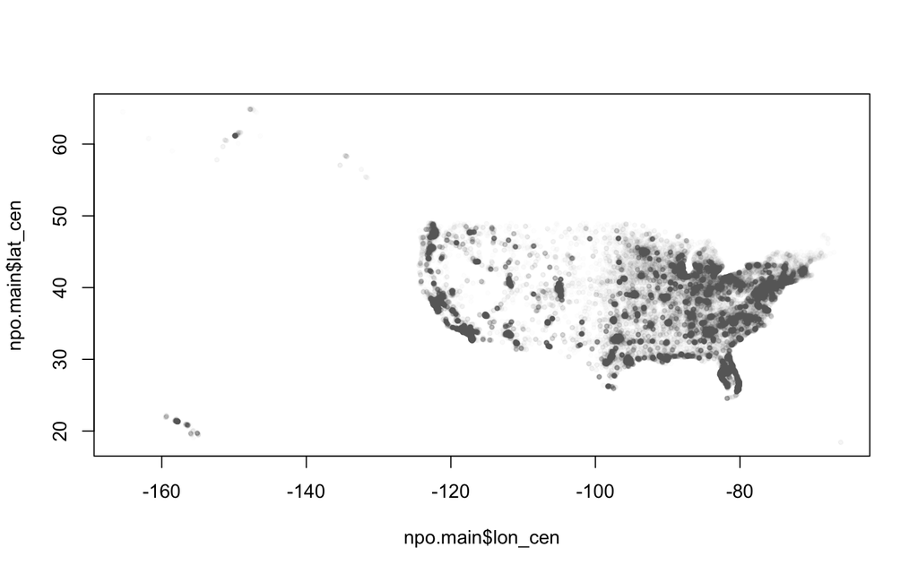

```r
# uploading the file in case needed
# npo.main <- readRDS("Data/3_GeoCensus/NONPROFITS-2014-2019v3.rds")

plot( npo.main$lon_cen, npo.main$lat_cen, pch=19, cex=0.5, col=gray(0.5,0.01))
```

Summary of geocode (all):

There are 263272 NPO listed. with 256527 unique addresses

```r
#Summary
x <- table(npo.main$match, useNA = "always")
y <- prop.table(table(npo.main$match, useNA = "always"))

summary <- as.data.frame(t(rbind(x,y)))
colnames(summary) <- c("frequency", "percent")
summary$percent <- summary$percent*100
summary[nrow(summary)+1,] <- c(sum(summary$frequency), 100)
rownames(summary)[nrow(summary)] <- "TOTAL"
pander(summary)
```

|  | frequency | percent |
| --- | --- | --- |
| **Match** | 182042 | 69.15 |
| **No_Match** | 62215 | 23.63 |
| **Tie** | 3380 | 1.284 |
| **NA.** | 15635 | 5.939 |
| **TOTAL** | 263272 | 100 |

The following numbers of POBs

```r
x <- round(prop.table(table(npo.main$pob, useNA = "ifany"))*100,1)
names(x) <- c("Non-POB", "POB")
pander(x)
```

| Non-POB | POB |
| --- | --- |
| 87.6 | 12.4 |

Summary of geocode excluding POBs:

```r
x <- which(npo.main$pob == 0)
npo.main1 <- npo.main[x,]

#Summary
x <- table(npo.main1$match, useNA = "always")
y <- prop.table(table(npo.main1$match, useNA = "always"))

summary <- as.data.frame(t(rbind(x,y)))
colnames(summary) <- c("frequency", "percent")
summary$percent <- summary$percent*100
summary[nrow(summary)+1,] <- c(sum(summary$frequency), 100)
rownames(summary)[nrow(summary)] <- "TOTAL"
pander(summary)
```

|  | frequency | percent |
| --- | --- | --- |
| **Match** | 180999 | 78.5 |
| **No_Match** | 32866 | 14.25 |
| **Tie** | 3302 | 1.432 |
| **NA.** | 13409 | 5.815 |
| **TOTAL** | 230576 | 100 |

Summary of geocode for only POBs:

```r
x <- which(npo.main$pob == 1)
npo.main2 <- npo.main[x,]

#Summary
x <- table(npo.main2$match, useNA = "always")
y <- prop.table(table(npo.main2$match, useNA = "always"))

summary <- as.data.frame(t(rbind(x,y)))
colnames(summary) <- c("frequency", "percent")
summary$percent <- summary$percent*100
summary[nrow(summary)+1,] <- c(sum(summary$frequency), 100)
rownames(summary)[nrow(summary)] <- "TOTAL"
pander(summary)
```

|  | frequency | percent |
| --- | --- | --- |
| **Match** | 1043 | 3.19 |
| **No_Match** | 29349 | 89.76 |
| **Tie** | 78 | 0.2386 |
| **NA.** | 2226 | 6.808 |
| **TOTAL** | 32696 | 100 |

# 4. Geocoding Board Member (PPL) addresses

Uploading the file **PPLAddresses_census.rds**

```r
ppl <- readRDS( "Data/3_GeoCensus/PPLAddresses_census.rds" )
```

## 4.1 Dividing the addresses in batches of 500 each

```r
# Create the folders to hold geocoding results if needed:
# dir.create( "Data/3_GeoCensus/addresses_ppl")
# dir.create( "Data/3_GeoCensus/addresses_ppl/2014-2019")

#setting wd
wd2 <- paste0(wd, "/Data/3_GeoCensus/addresses_ppl/2014-2019")
setwd(wd2)

# Selecting only essential variables
ppl <- select( ppl, ID, Address, City, State, Zip )

# we remove colnames because input file should not have names
names( ppl ) <- NULL

# Spliting address files into files with 500 addresses each
loops <- ceiling( nrow( ppl ) / 500 ) # ceiling function rounds up an integer. so loops has the amount of 500s that fit rounded up.

# loop to extract by addressess in 500 batches
for( i in 1:loops )
  {
  filename <- paste0( "AddressPPL",i,".csv" )
  start.row <- ((i-1)*500+1) # i starts in 1 and this outputs: 1, 501, 1001, etc.
  end.row <- (500*i) # this outputs 500, 1000, etc.
  if( nrow(ppl) < end.row ){ end.row <- nrow(ppl) } # this tells the loop when to stop

  # writing a line in the csv address file.
  write.csv( ppl[ start.row:end.row, ], filename, row.names=F )

  # output to help keep track of the loop.
  print( i )
  print( paste( "Start Row:", start.row ) )
  print( paste( "End Row:", end.row ) )
} # end of loop.

setwd(wd)
```

## 4.2 Geocoding PPL addresses

Passing the addresses files produced through the census geocode srvice. This will output the following per each address file:

- **Rresults[i].csv**, with raw geocode results and
- **RresultsPPL[i].csv**, wich has the same data but with splitted lat/lon fields.

In addition, a **Geocode_Log.txt** will be created for the whole process.

```r
# create a folder for ppl census geocoding files if needed:
# dir.create( "Data/3_GeoCensus/addresses_ppl/2014-2019/Results" )

# setting wd
wd2 <- paste0(wd, "/Data/3_GeoCensus/addresses_ppl/2014-2019")
setwd(wd2)

# producing LOG file
log <- c("Query_Number", "Start_time", "Time_taken")
log <- paste(log, collapse=',')
log.name <- as.character(Sys.time())
log.name <- gsub(":","-",log.name)
log.name <- gsub(" ","-",log.name)
log.name <- paste0("Results/Geocode_Log_",log.name,".txt")
write(log, file=log.name, append = F)

#Geocoding loop:
for( i in 1:loops )
  {
  #creating the objects that will be used in each iteration of the loop: file name of addresses and api
  addressFile <- paste0( "AddressPPL",i,".csv" )
  apiurl <- "https://geocoding.geo.census.gov/geocoder/geographies/addressbatch"

  #outputs in console to track loop
  print( i )
  print(Sys.time() )
  start_time <- Sys.time()

  #Geocode query for i. Query is wrapped with try function to allow error-recovery
  try(
    resp <- POST( apiurl,
                  body=list(addressFile=upload_file(addressFile),
                            benchmark="Public_AR_Census2010",
                            vintage="Census2010_Census2010",
                            returntype="csv" ),
                            encode="multipart" )
    )

  #documenting ending times
  end_time <- Sys.time()
  print( end_time - start_time ) #ouputting in R console

  #writing a line in the log file after query i ends
  query <- as.character(i)
  len <- as.character(end_time - start_time)
  start_time <- as.character(start_time)
  log <- c(query, start_time, len)
  log <- paste(log, collapse=',')
  write(log, file=log.name, append = T)

  #constructing the Results[i].csv filename.
  addressFile2 <- paste0( "Results/Results",i,".csv" )

  #creating column names to include in the results csv file
  var_names <- c( "id", "input_address",
                  "match", "match_type",
                  "out_address", "lat_lon",
                  "tiger_line_id", "tiger_line_side",
                  "state_fips", "county_fips",
                 "tract_fips", "block_fips" )
  v.names <- paste(var_names, collapse=',')

  #writing Rresults[i].csv, including headers
  writeLines( text=c(v.names, content(resp)) , con=addressFile2 )

  #reading file
  res <- read.csv( addressFile2, header=T,
                 stringsAsFactors=F,
                 colClasses="character" )

  # Splitting latitude and longitude values from results (res) to a variable (lat.lon)
  lat.lon <- strsplit( res$lat_lon, "," )

  #adding NAs to lat.lon empty fields
  for( j in 1:length(lat.lon) )
    {
    if( length( lat.lon[[j]] ) < 2 )
      lat.lon[[ j ]] <- c(NA,NA)
    }

  #tranforming the splitted lat.lons to columns that can be binded to a dataframe
  m <- matrix( unlist( lat.lon ), ncol=2, byrow=T )
  colnames(m) <- c("lon","lat")
  m <- as.data.frame( m )

  #Adding lat and lon values to raw results and writing ResultsPPL[i].csv file
  res <- cbind( res, m )
  write.csv( res, paste0("Results/ResultsPPL",i,".csv"), row.names=F )

  } # end of loop

# setting back wd
setwd(wd)
```

## 4.3 Combining Result Files

This code chunk compiles all results and saves them into **PPLAddresses_censusGEO.rds**.

```r
# setting wd
wd2 <- paste0(wd, "/Data/3_GeoCensus/addresses_ppl/2014-2019/Results")
setwd(wd2)

#capturing filenames of all elements in dir() that have "Resultsppl"
x <- grepl("ResultsPPL", dir())
these <- (dir())[x]

#loading first file in the string vector
ppl <- read.csv( these[1], stringsAsFactors=F )

#compiling all Results into one
for( i in 2:length(these) )
  {
  d <- read.csv( these[i], stringsAsFactors=F )
  ppl <- bind_rows( ppl, d )
  }

#saving compiled geocodes
saveRDS( ppl, "../../PPLAddresses_censusGEO.rds" )
setwd(wd)
```